# Drosophila Traumatic Brain Injury

Anji Trujillo - Professor Coon

December 8, 2018

This is an R Markdown Document describing the proteomics data collected for the Drosophila Traumatic Brain Injury Project in collaboration with Professor Wassarman and Becky Steinbrech. The samples analyzed were derived from heads and hemolymph of Drosophilla melanogaster. For the head samples, there are 17 time points with a control and a traumatic brain injury (TBI) sample at each time point. The hemolymph sample is a shorter temporal study with control and traumatic brain injury samples for 4 time points.

The head and hemolymph data was searched separately with an appropriate fractionated sample to increase our protein group resolution.

## Load data

```
## Number of protein groups in Hemolymph Data before any filtering of missing measurements: 9746
```

```
## Number of protein groups in Heads Data before any filtering of missing measurements: 10290
```

The data analysis was performed using R. The following functions were written to manipulate the data:  
1. Remove Contaminants and Reverse Sequences  
2. Subset columns only with protein ID’s, number identifier, and Gene Name  
3. 50% data cut off, filters data to exclude proteins that have more than 50% of measurements missing 4. Plotting Standard Deviation of Proteins 5. Fuzzy c-means preperation for data that has not been imputed yet  
6. Fuzzy c-means for data that has been previously imputed (in this case Bayesian Statistics from PCAMethods package)

## Hemolymph Data

The hemolymph data includes samples for the first 24 hours (1,4,8,24 hrs) after traumatic brain injury has been implemented. The data analysis will:  
1. Clean proteomics data from MaxQuant search algorithm output  
2. Distribution of proteomic data before and after Bayesian imputation.  
3. PCA plots describing the variation in protein groups (scores) and the variation in the samples (loading) 4. Fuzzy Clustering and hierarchical plots  
5. Clustering is also performed on fold change data

Number of missing measurement in Hemo dataset: 31443

Filter and exclude protein groups that are missing over 50% of measurements

```
## [1] "Number of protein groups that have over 50% missing measurements: 3151"
## [1] "Protein groups that pass the 50% filteration: 6030"
## [1] "Number of protein groups removed from dataset: 3151"
```

Implement a bayesian pca imputation for data that is log2 transformed. The R package used is called [pcaMethod](https://www.bioconductor.org/packages/devel/bioc/manuals/pcaMethods/man/pcaMethods.pdf).

```r
#PCA function utelizing method=bpca "bayesian"
pc_hemolog2 <- pca(hemo_50percent_log2, nPcs = 3, method = "bpca") #pca method
#extract imputed data set for hemo data
imputed_hemo <- completeObs(pc_hemolog2)

write.csv(imputed_hemo, "E:/Projects/Proteomics/DorsophilaHead_Experiment/Imputed_hemo_log2.csv")
```

The distribution of the data bfore and after Bayesian imputation, plotted below.

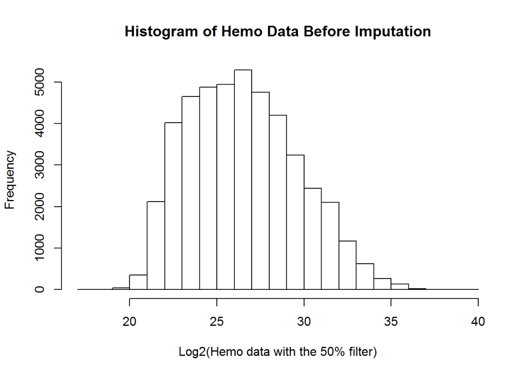

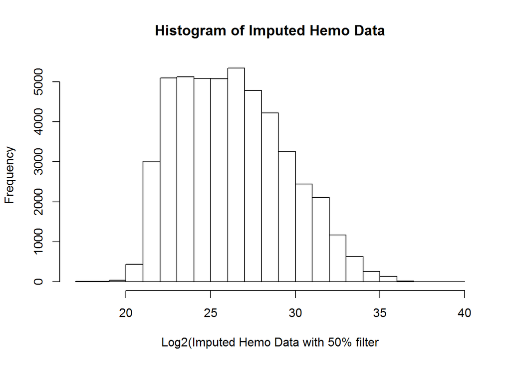

A global view of the data can visualized by PCA analysis. Imputed data is used from here on forward  
* The first PCA is a plot where each dot represents a protein (6,030 proteins), the text denote which sample the protein group derives from, and the color indicates either control or TBI sample type.  
* In the second PCA plot the loadings describe the variance in each of the hemolymph samples determined by protein group. Each dot is a hymolymph sample and the color indicates either control or TBI sample type.

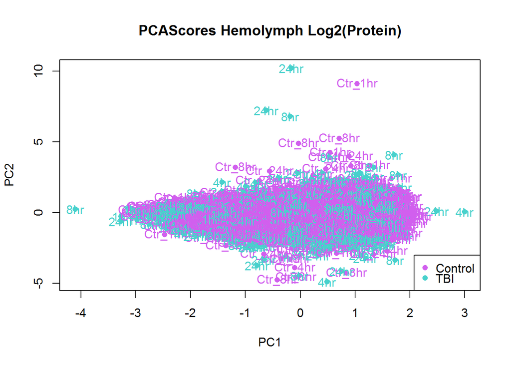

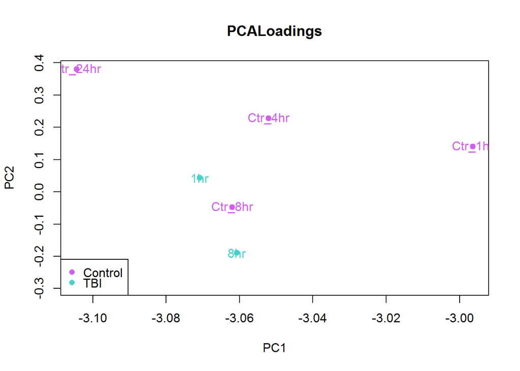

## Hemo mFuzz Soft Clustering

Clustering will be implemnted on the proteomics data set that that has been organized such that control samples are the first and TBI samples are following.

Prior to fuzzy clustering the variation for each protein plotted.

```
## 96 Proteins have a standard deviation greater than  0.1 .
```

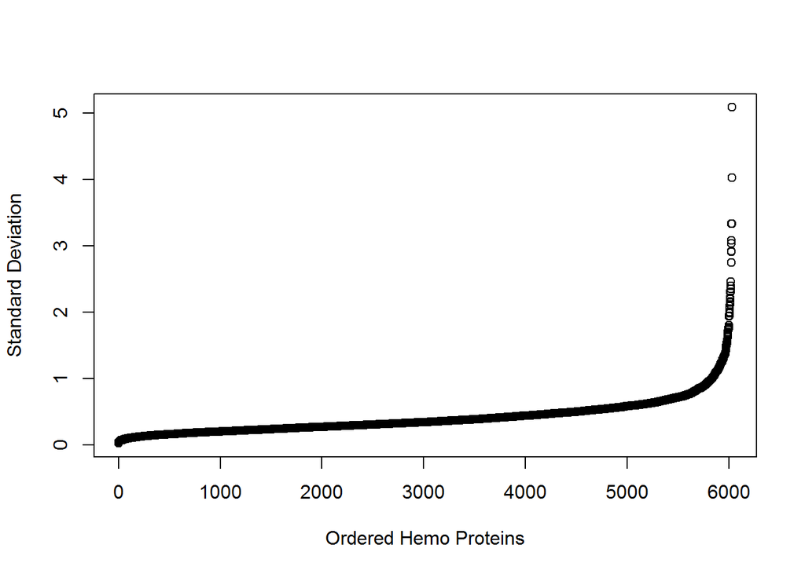

Soft clustering is implemented in the function mfuzz using a fuzzy c-means algorithm from [e1071](https://cran.r-project.org/web/packages/e1071/e1071.pdf) package.

Fuzzy clustering is one many types of clustering algoriths to choose from e.g. K-means, hierarchical, bayesian, etc. I will show fuzzy clustering along with hierarchical clustering to visualize the protein trends we see for through out the timepoint. The clustering will be performed first on data set that includes both the control and TBI samples and then performed on the fold change data relative to control.

To begin th we must first optimize the parameters for fuzzy clustering we must calculate the fuzzier value as well as the number of clusters to divide the data into. The fuzzier “m” and the number of clusters “c” must be chosen in advanced. This fuzzy type of clustering is advantageous over hard cluster (e.g. k-means) which commonly detects clusters of random data.

The function mestimate

```
## [1] "fuzzier m = 1.4410339130003"
```

```r
# Find the error associated with number of cluster 2-15
for(i in 2:15){
  c1 <- mfuzz(y, c=i, m=m1)
  error <- rbind(error, c(i,c1$withinerror))
}
```

Look at the error calculated for each of the clusters.

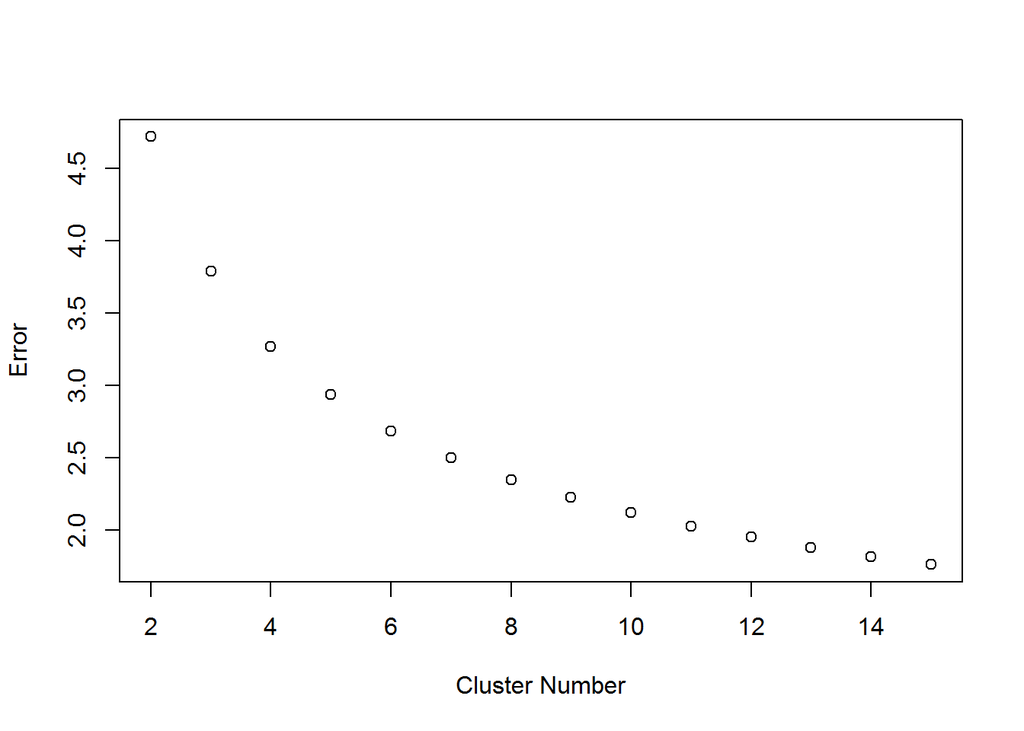

Fuzzy clusters are plotted for 6 clusters.  
*Note first 4 samples are Controls and next set of 4 are TBI samples*  
Note a seed has been set to keep clusters consistent.

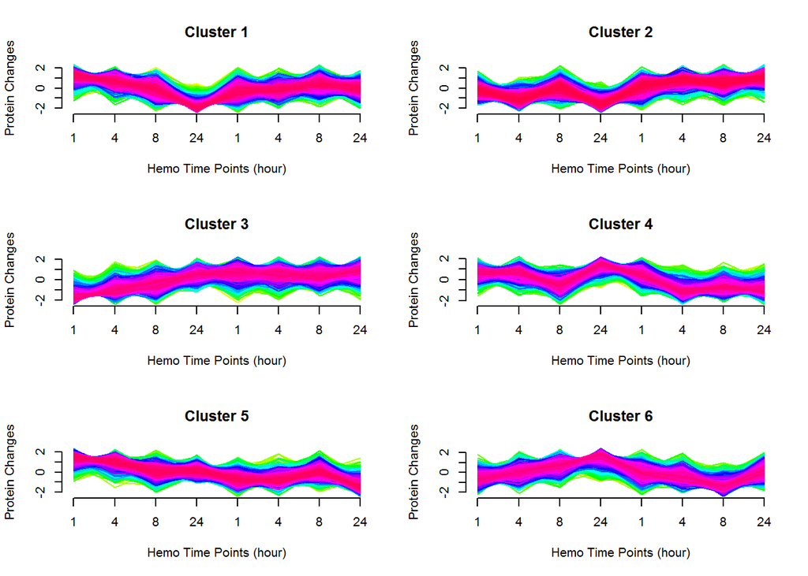

Filter out proteins from clusters with a membership score of greater than 70%. Accounting for the majority of the temporal trend.

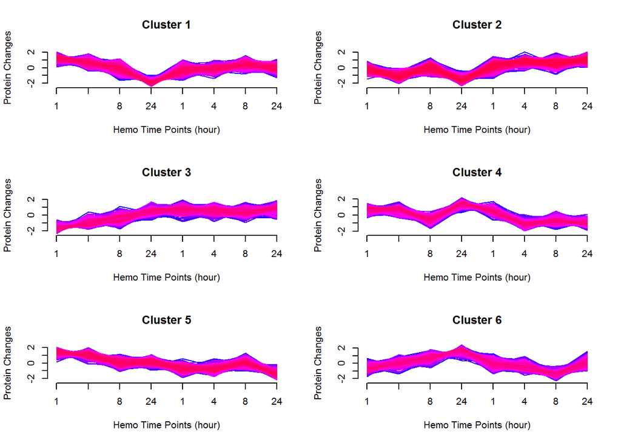

How many proteins have a membership score greater than 70%, count TRUE.

```
##
## FALSE  TRUE
##  4114  1916
```

Heat map of hemo samples that have a membership value greater than 70%. Global view of hemo samples.

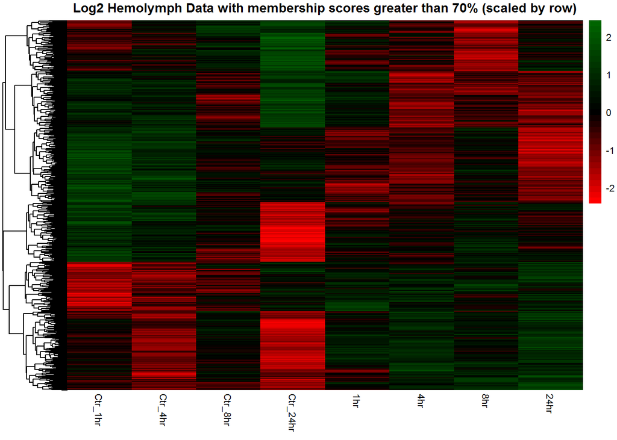

## Hemo mFuzz Soft Clustering - fold change

Fuzzy clustering is performed on fold change data set. The fold change was calculated relative to controls. We will look at clustering of proteins that have a fold change greater than 1.2. There are fold changes in the hemolymph data that are greater than 8, and these proteins with extreme fold changes must be looked at in depth. However to reduce their bias on clustering, I have implemented a binning strategy that takes a look at the data set between logfold -2 and 2, compressing the larger fold changes down to fold change of 2.1. This way we can see how the protein groups bin at a more granular level.

I have added fuzzy clustering at the end of this section, however I dont believe fuzzy clustering will be the best strategy for visualizing the clusters. There are hierarchical clusters and a clusplot at the beginning of this section, to help determine the number of clusters the data partitions into.

```r
imputed_hemo_fold <- imputed_hemo_reorder[,5:8]-imputed_hemo_reorder[,1:4]

write.csv(imputed_hemo_fold, "E:/Projects/Proteomics/DorsophilaHead_Experiment/Imputed_hemo_foldchange.csv")

# subset features with fold change greater than 1.2 to cluster
important_features_hemo_foldchange <- imputed_hemo_fold[rowSums(abs(imputed_hemo_fold)>1.2)>0,]

# bin protein groups so that we describe the changes within fold changes of -2 and 2
important_features_foldchange_compress <- important_features_hemo_foldchange
important_features_foldchange_compress[important_features_foldchange_compress < -2] = -2.1
important_features_foldchange_compress[important_features_foldchange_compress > 2] = 2.1

# Protein groups with fold change greater than 1.2
table(rowSums(abs(imputed_hemo_fold)>1.2)>0)
```

```
##
## FALSE  TRUE
##  4522  1508
```

```r
# Protein groups with fold change greater than 2
table(rowSums(abs(imputed_hemo_fold)>2)>0)
```

```
##
## FALSE  TRUE
##  5661   369
```

```r
# Protein groups with fold change greater than 4
table(rowSums(abs(imputed_hemo_fold)>4)>0)
```

```
##
## FALSE  TRUE
##  5984    46
```

```r
# Protein groups with fold change greater than 8
table(rowSums(abs(imputed_hemo_fold)>8)>0)
```

```
##
## FALSE  TRUE
##  6027     3
```

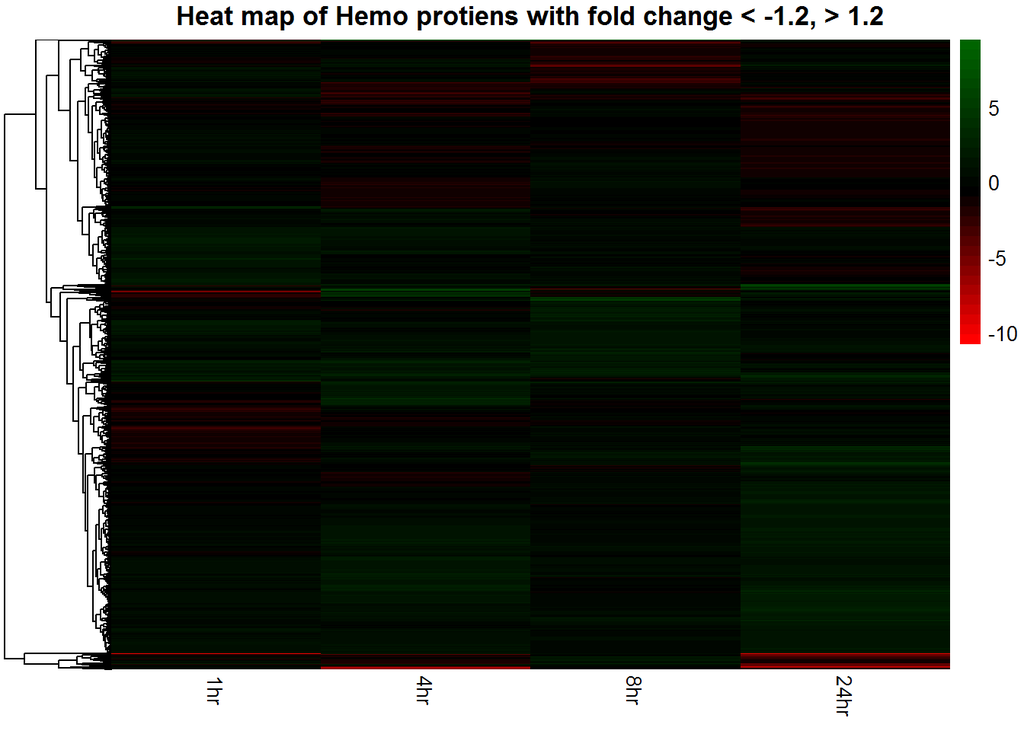

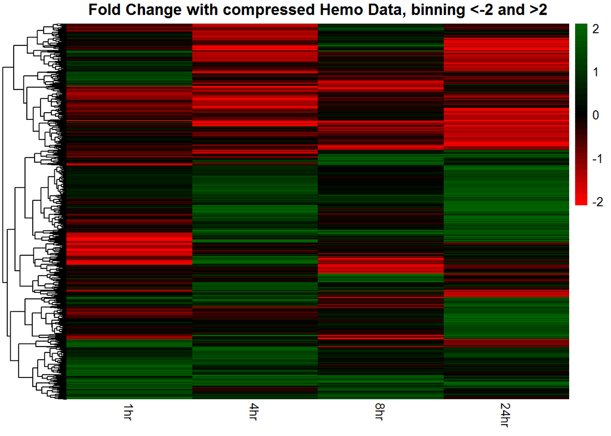

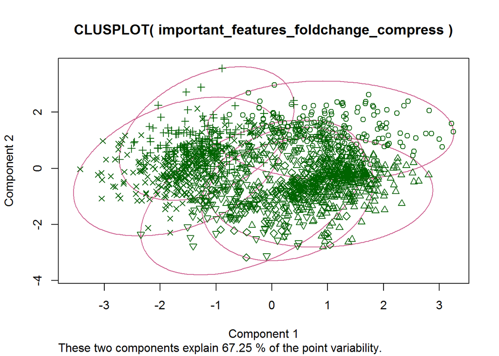

```r
fold_hclust <- hclust(dist(important_features_foldchange_compress, method = "euclidean"))
clusters <- cutree(fold_hclust, k = 6) #k = 20)

clusplot(important_features_foldchange_compress, clusters, lines = 0)
```

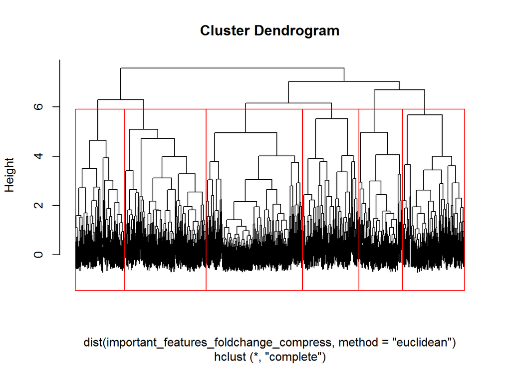

```r
plot(fold_hclust, label= FALSE)
rect.hclust(fold_hclust, k=6, border = "red")
```

# Fold Change Hemo Data Fuzzy Clustering

```r
#start with the re-ordered hemo data
z = important_features_foldchange_compress # change accordingly to use in mfuzzy setup funtions

exprValues.s_bayesian <- fuzzyprep_usepreviousImputation_foldchange(z)
```

```
## 1 Proteins have a standard deviation greater than  0.1 .
```

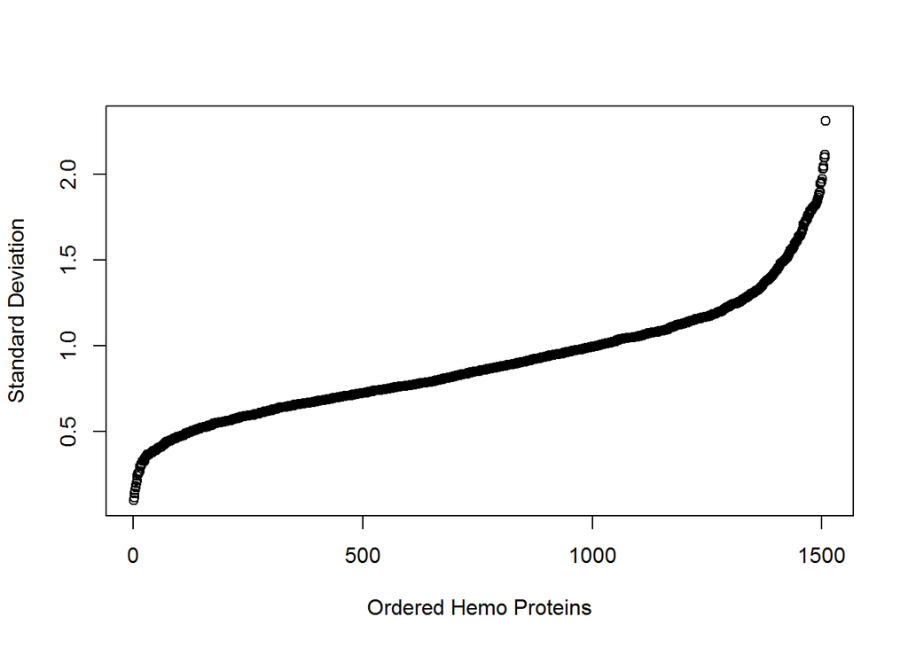

```r
error <- NA #set error to NA

y = exprValues.s_bayesian #change according to version of data to perform fuzzy clustering
```

The function mestimate

```r
m1 <- mestimate(y)

#
for(i in 2:15){
  c1 <- mfuzz(y, c=i, m=m1)
  error <- rbind(error, c(i,c1$withinerror))
}
```

Plot error calculated from imputed hemo data set that has been reordered.

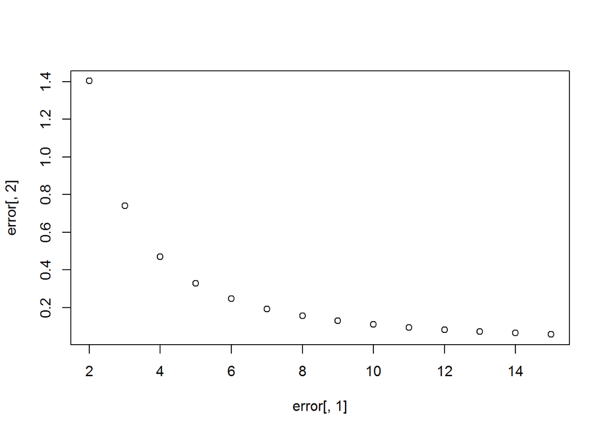

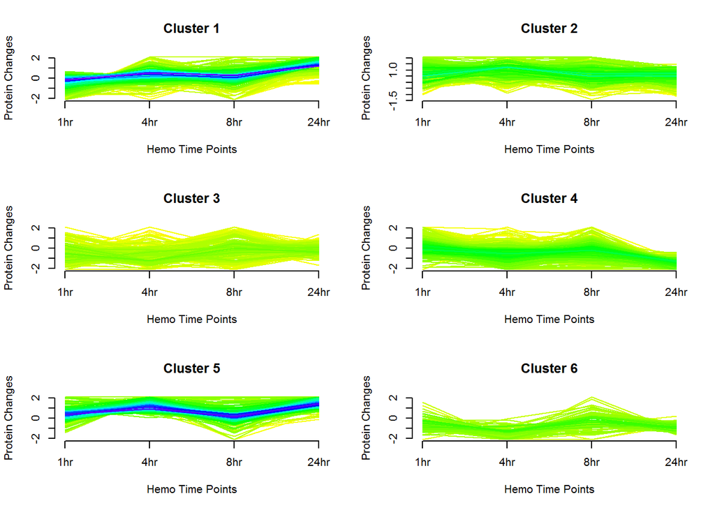

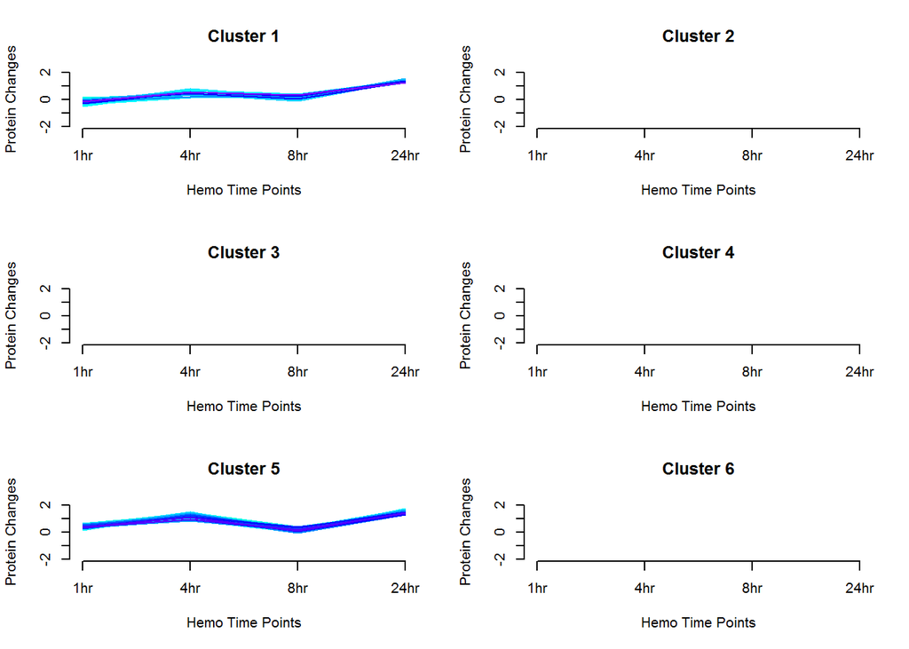

## Head Data

```r
proteinGroups_dros_heads <- RemoveContaminants(proteinGroups_dros_heads)
print(dim(proteinGroups_dros_heads))
```

```
## [1] 9365  335
```

```r
proteinGroups_dros_heads <- subsetLFQ(proteinGroups_dros_heads)
print(dim(proteinGroups_dros_heads))
```

```
## [1] 9365   38
```

Number of missing measurement in Head dataset: 83521

Filter and exclude protein groups that are missing over 50% of measurements

```
## [1] "Number of protein groups that have over 50% missing measurements: 2190"
## [1] "Protein groups that pass the 50% filteration: 7175"
## [1] "Number of protein groups removed from dataset: 2190"
```

Implement a bayesian pca imputation for data that is log2 transformed. The R package used is called [pcaMethod](https://www.bioconductor.org/packages/devel/bioc/manuals/pcaMethods/man/pcaMethods.pdf).

```r
#subset matrix containing only samples that have been filtered 50% threshold
head_50percent <- as.matrix(filtered_dros_head_50percent[,c(5:38)])
#log2 transform
head_50percent_log2 <- log2(head_50percent)
#set row names to match protein group identifer number
rownames(head_50percent_log2) <- filtered_dros_head_50percent$id

colnames(head_50percent_log2) <- as.numeric(gsub(".*_","",colnames(head_50percent_log2)))

col_levels <- levels(colnames(head_50percent_log2)) <- seq(1:34)
colnames(head_50percent_log2) <- order(colnames(head_50percent_log2))

col_names <- names(colnames(head_50percent_log2)) <- order(colnames(head_50percent_log2))

head_meta <- data.frame(HeadTimePoints = order(col_levels),Sample_Type=rep(c("Control","TBI"),17))

head_50percent_log2 <- head_50percent_log2[,names(colnames(head_50percent_log2))]
```

```r
#PCA function utelizing method=bpca "bayesian"
pc_headlog2 <- pca(head_50percent_log2, nPcs = 3, method = "bpca") #pca method
#extract imputed data set for hemo data
imputed_head <- completeObs(pc_headlog2)

write.csv(imputed_head, "E:/Projects/Proteomics/DorsophilaHead_Experiment/Imputed_head.csv")
```

A global view of the data can visualized by PCA analysis. Imputed data is used from here.  
* The first PCA is a plot where each dot represents a protein (7,175 proteins), the text denote which timepoint the protein group derives from, and the color indicates either control or TBI sample type.  
* In the second PCA plot the loadings describe the variance in each of the brain samples determined by protein group. Each dot is a drosphila sample and the color indicates either control or TBI sample type.

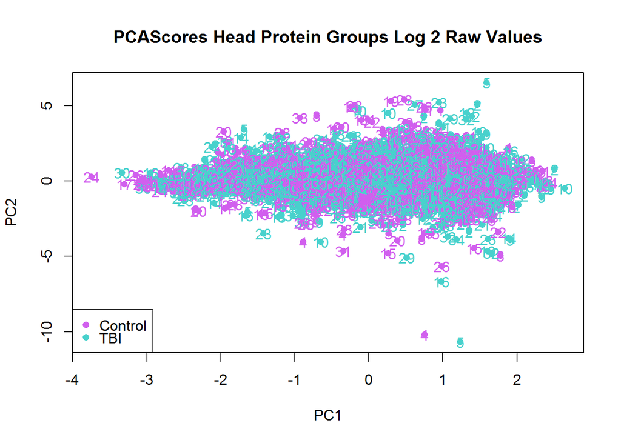

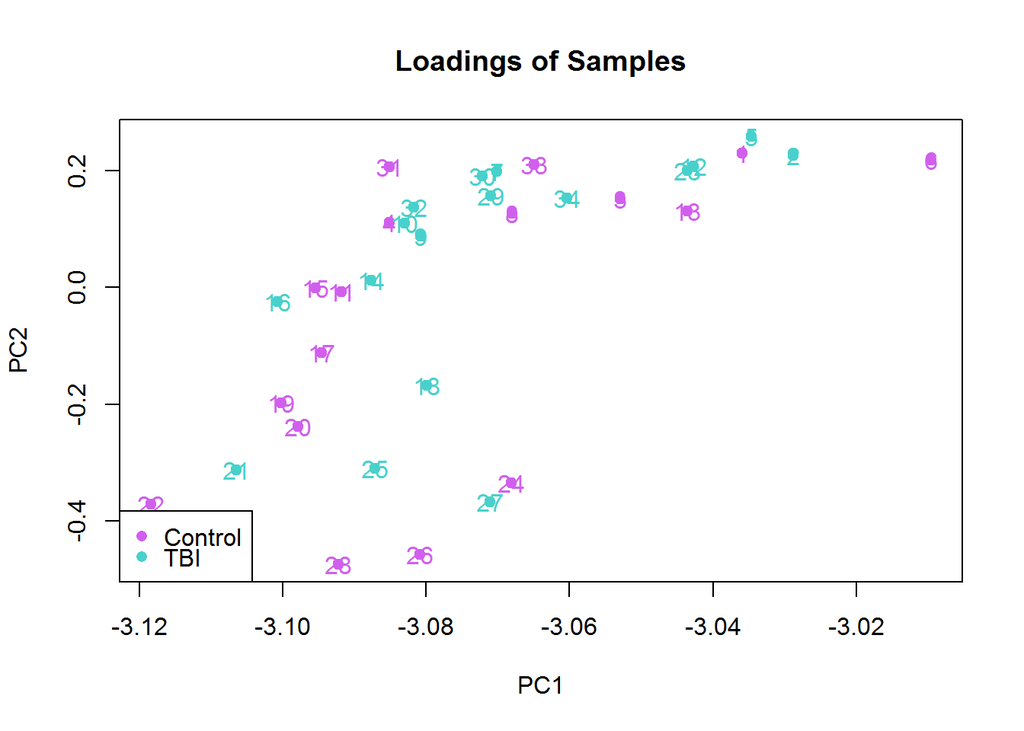

The distribution of the data is plotted below before and after imputation

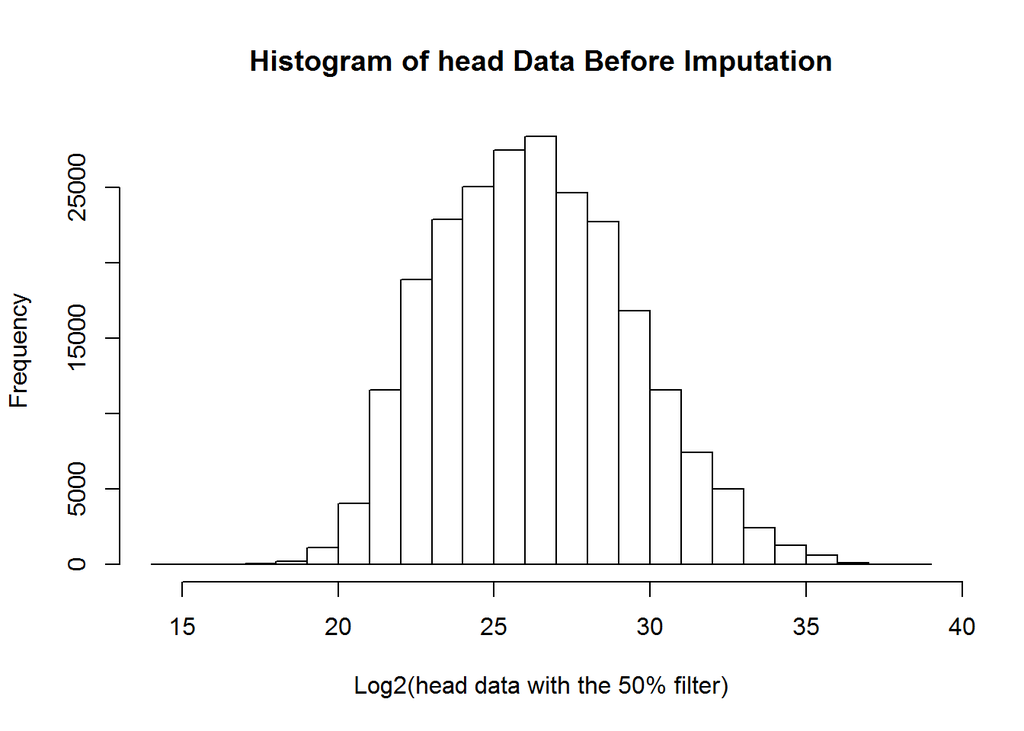

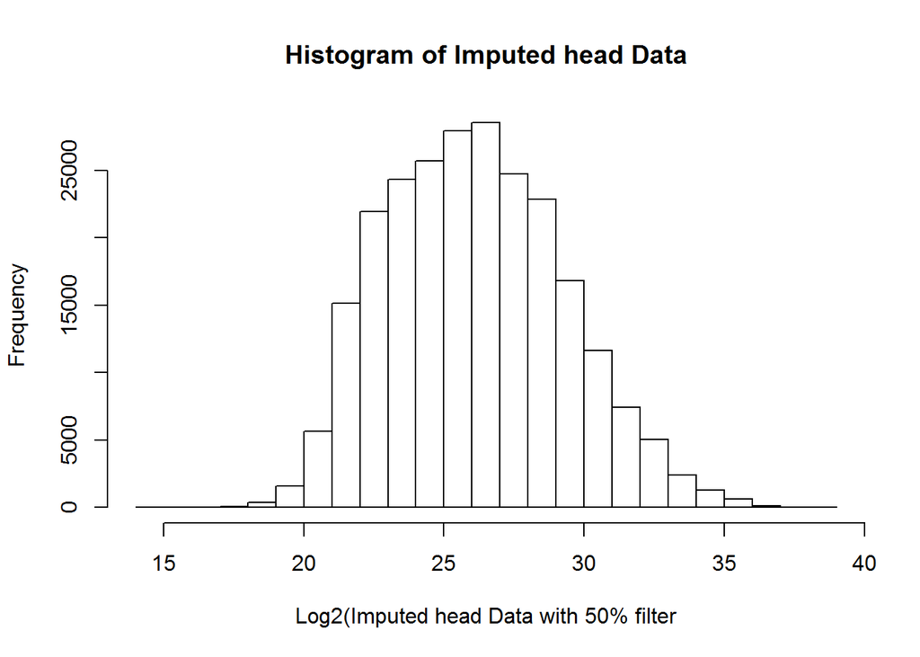

## Head mFuzz Soft Clustering

Clustering will be implemnted on data set that contains control samples first 17 and TBI samples remaining 17.

First we will look at the variation of the data by calculating the standard deviation of each protein.

```
## 105 Proteins have a standard deviation greater than  0.1 .
```

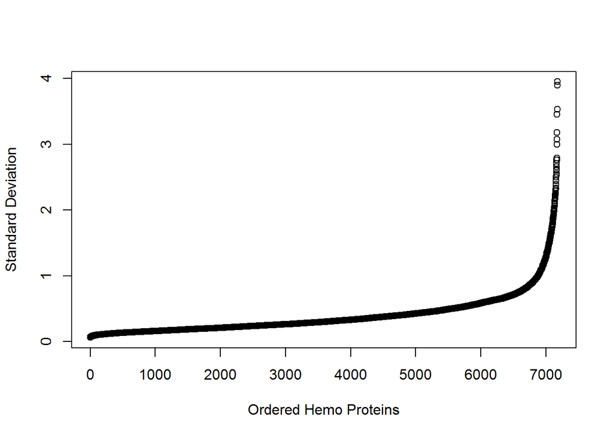

Soft clustering is implemented in the function mfuzz using a fuzzy c-means algorithm from e1071 package.

To optimize the parameters for fuzzy clustering we must calculate the fuzzier value as well as the number of clusters to divide the data into. The fuzzier “m” and the number of clusters “c” must be chosen in advanced. For “m” we choose a value that prevents clustering of random data. This fuzzy type of clustering is advantageous over hard cluster (e.g. k-means) which commonly detects clusters of random data.

The function mestimate

```
## [1] "fuzzier m = 1.065266572006"
```

```r
# Find the error associated with number of cluster 2-15
for(i in 2:20){
  c1 <- mfuzz(y, c=i, m=m1)
  error <- rbind(error, c(i,c1$withinerror))
}
```

Plot error calculated from the number of clusters used.

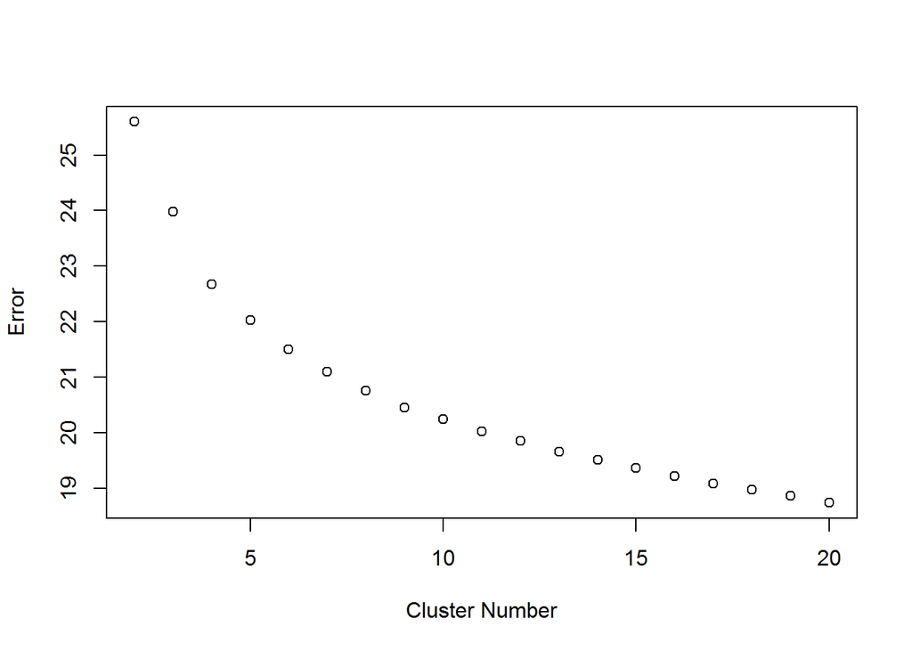

Fuzzy clusters are plotted for 12 clusters.  
*Note first 17 samples are Controls and next set of 17 are TBI samples*  
Note a seed has been set to keep clusters consistent.

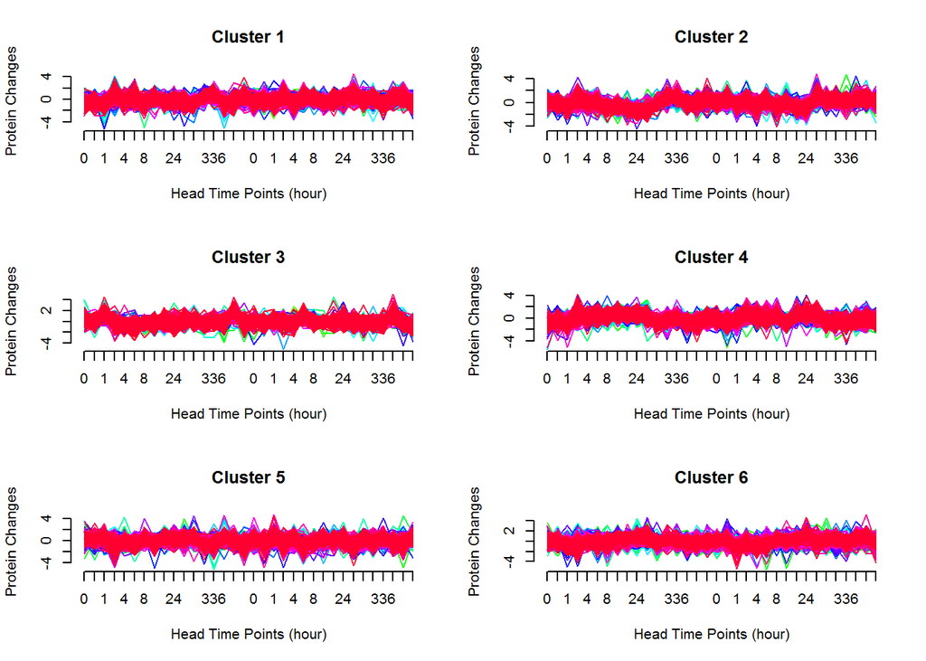

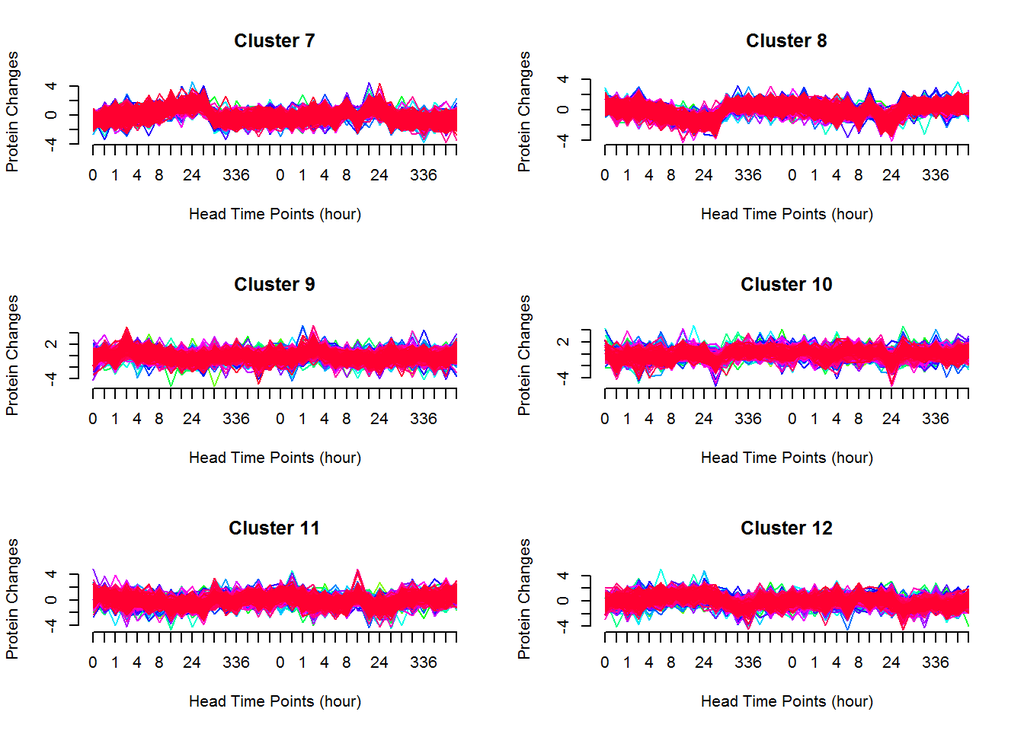

How many proteins have a membership score greater than 70%, count TRUE.

```
##
## FALSE  TRUE
##  2023  5152
```

Heat map of head samples that have a membership value greater than 70%. Global view of head samples.

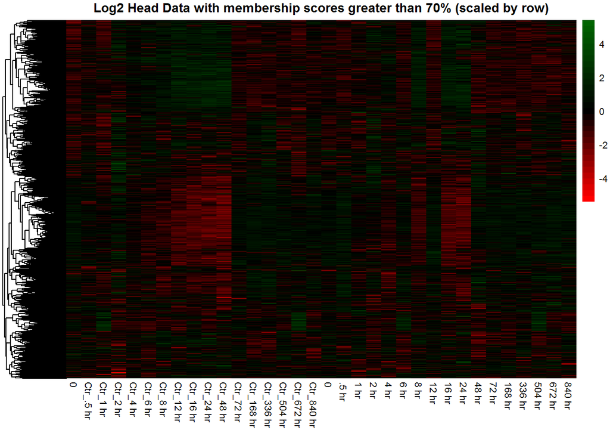

## Head mFuzz Soft Clustering - fold change

```r
imputed_head_fold <- imputed_head_reorder[,18:34]-imputed_head_reorder[,1:17]

write.csv(imputed_head_fold, "E:/Projects/Proteomics/DorsophilaHead_Experiment/Imputed_head_foldchange.csv")

# subset features with fold change greater than 1.2 to cluster
important_features_head_foldchange <- imputed_head_fold[rowSums(abs(imputed_head_fold)>1.2)>0,]

# Protein groups with fold change greater than 1.2
table(rowSums(abs(imputed_head_fold)>1.2)>0)
```

```
##
## FALSE  TRUE
##  4807  2368
```

```r
# Protein groups with fold change greater than 2
table(rowSums(abs(imputed_head_fold)>2)>0)
```

```
##
## FALSE  TRUE
##  6196   979
```

```r
# Protein groups with fold change greater than 4
table(rowSums(abs(imputed_head_fold)>4)>0)
```

```
##
## FALSE  TRUE
##  6958   217
```

```r
# Protein groups with fold change greater than 8
table(rowSums(abs(imputed_head_fold)>8)>0)
```

```
##
## FALSE  TRUE
##  7151    24
```

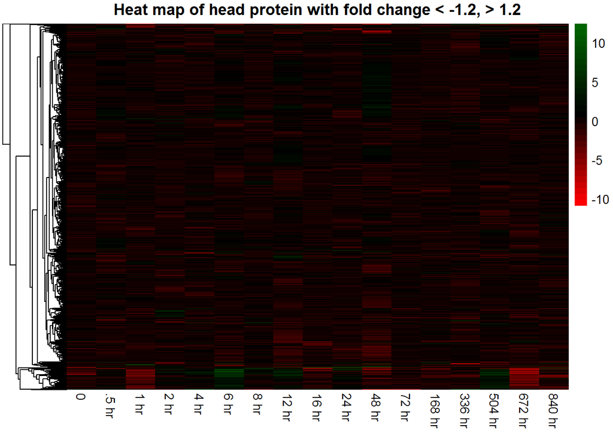

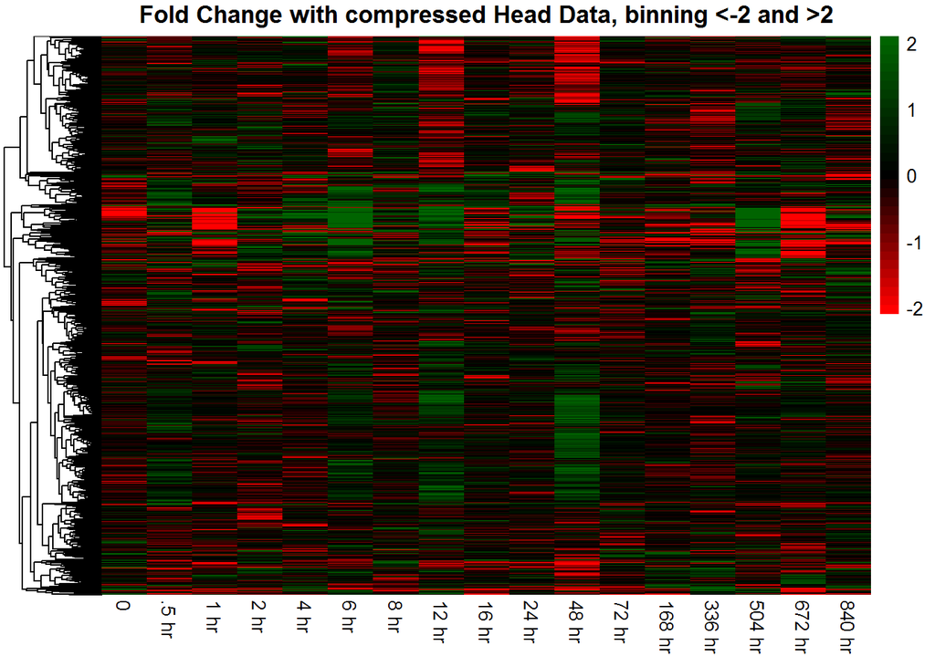

```r
# bin protein groups so that we describe the changes within fold changes of -2 and 2
important_features_foldchange_compress <- important_features_head_foldchange
important_features_foldchange_compress[important_features_foldchange_compress < -2] = -2.1
important_features_foldchange_compress[important_features_foldchange_compress > 2] = 2.1
```

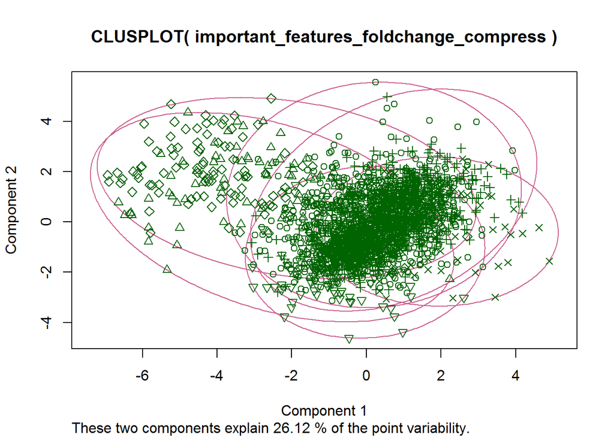

```r
fold_hclust <- hclust(dist(important_features_foldchange_compress, method = "euclidean"))
clusters <- cutree(fold_hclust, k = 6) #k = 20)

clusplot(important_features_foldchange_compress, clusters, lines = 0)
```

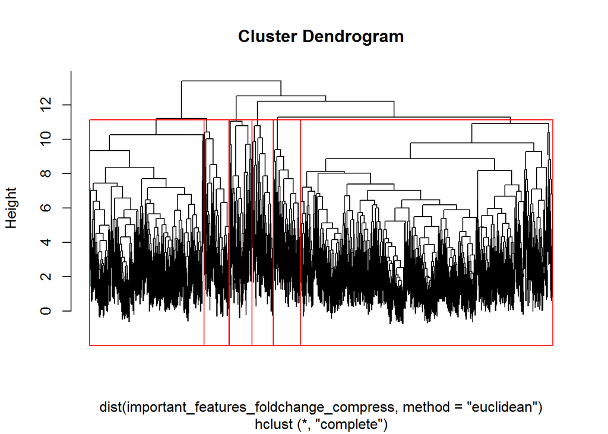

```r
plot(fold_hclust, label= FALSE)
rect.hclust(fold_hclust, k=6, border = "red")
```